## The Costs, Both Economic and Human, of Weather Events in the US

Evaluated storm data from the National Weather Service of NOAA, focusing on the human casualties and the economic damage related to weather events.

### Data Processing

I got the data from [here](https://d396qusza40orc.cloudfront.net/repdata%2Fdata%2FStormData.csv.bz2).

```r
stormdata <- read.csv(bzfile("repdata-data-StormData.csv.bz2"))
```

Let’s look at the variable names.

```r
names(stormdata)
```

```
##  [1] "STATE__"    "BGN_DATE"   "BGN_TIME"   "TIME_ZONE"  "COUNTY"
##  [6] "COUNTYNAME" "STATE"      "EVTYPE"     "BGN_RANGE"  "BGN_AZI"
## [11] "BGN_LOCATI" "END_DATE"   "END_TIME"   "COUNTY_END" "COUNTYENDN"
## [16] "END_RANGE"  "END_AZI"    "END_LOCATI" "LENGTH"     "WIDTH"
## [21] "F"          "MAG"        "FATALITIES" "INJURIES"   "PROPDMG"
## [26] "PROPDMGEXP" "CROPDMG"    "CROPDMGEXP" "WFO"        "STATEOFFIC"
## [31] "ZONENAMES"  "LATITUDE"   "LONGITUDE"  "LATITUDE_E" "LONGITUDE_"
## [36] "REMARKS"    "REFNUM"
```

For this analysis, we care most about events and their human and economic costs across the United States. Let’s take a look at those variables.

First, the events.

```r
unique(stormdata$EVTYPE)[1:5]
```

```
## [1] TORNADO       TSTM WIND     HAIL          FREEZING RAIN SNOW
## 985 Levels:    HIGH SURF ADVISORY  COASTAL FLOOD ... WND
```

Nearly 1000 different event types and those types are as expected. With more time, perhaps figure out how to aggregate similar events.

Next, the human costs. There are two variables that matter to us.

```r
str(stormdata$FATALITIES)
```

```
##  num [1:902297] 0 0 0 0 0 0 0 0 1 0 ...
```

```r
summary(stormdata$FATALITIES)
```

```
##     Min.  1st Qu.   Median     Mean  3rd Qu.     Max.
##   0.0000   0.0000   0.0000   0.0168   0.0000 583.0000
```

```r
str(stormdata$INJURIES)
```

```
##  num [1:902297] 15 0 2 2 2 6 1 0 14 0 ...
```

```r
summary(stormdata$INJURIES)
```

```
##      Min.   1st Qu.    Median      Mean   3rd Qu.      Max.
##    0.0000    0.0000    0.0000    0.1557    0.0000 1700.0000
```

No surprises there.

We will create a new variable called `CASUALTIES` which we define as the sum of `INJURIES` and 10 * `FATALITIES`. In estimating human cost, a single fatality should count much more than an injury.

```r
suppressMessages(library(dplyr))
#Start creating a subset of stormdata for specific analysis
stormdatatidy <- mutate(stormdata, CASUALTIES = FATALITIES * 10 + INJURIES)
summary(stormdatatidy$CASUALTIES)
```

```
##     Min.  1st Qu.   Median     Mean  3rd Qu.     Max.
##    0.000    0.000    0.000    0.324    0.000 5830.000
```

Let’s turn our attention to economic costs. Both property and crop damage count are economic costs.

First, property damage. Curiously, there are two variables which may matter.

```r
str(stormdata$PROPDMG)
```

```
##  num [1:902297] 25 2.5 25 2.5 2.5 2.5 2.5 2.5 25 25 ...
```

```r
summary(stormdata$PROPDMG)
```

```
##    Min. 1st Qu.  Median    Mean 3rd Qu.    Max.
##    0.00    0.00    0.00   12.06    0.50 5000.00
```

```r
str(stormdata$PROPDMGEXP)
```

```
##  Factor w/ 19 levels "","-","?","+",..: 17 17 17 17 17 17 17 17 17 17 ...
```

```r
summary(stormdata$PROPDMGEXP)
```

```
##             -      ?      +      0      1      2      3      4      5
## 465934      1      8      5    216     25     13      4      4     28
##      6      7      8      B      h      H      K      m      M
##      4      5      1     40      1      6 424665      7  11330
```

`PROPDMG` is a numeric vector as expected although the numbers seem low. Surprisingly, `PROPDMGEXP` is a 19 level factor variable. Let’s take a closer look.

```r
summarize(group_by(stormdata, PROPDMGEXP), count = n())
```

```
## Source: local data frame [19 x 2]
##
##    PROPDMGEXP  count
## 1             465934
## 2           -      1
## 3           ?      8
## 4           +      5
## 5           0    216
## 6           1     25
## 7           2     13
## 8           3      4
## 9           4      4
## 10          5     28
## 11          6      4
## 12          7      5
## 13          8      1
## 14          B     40
## 15          h      1
## 16          H      6
## 17          K 424665
## 18          m      7
## 19          M  11330
```

Almost all observations are either `K`, `M` or `EMPTY`. It’s reasonable to assume that `K` stands for thousands, `M` for millions and `EMPTY` for small (< $1000) amounts of damage or none at all. Let’s take a closer look.

```r
summarize(group_by(stormdata, PROPDMGEXP), count = format(n(), big.mark = ","), dollars = format(sum(PROPDMG), big.mark = ",", digits = "0", scientific = FALSE))
```

```
## Source: local data frame [19 x 3]
##
##    PROPDMGEXP   count    dollars
## 1             465,934        527
## 2           -       1         15
## 3           ?       8          0
## 4           +       5        117
## 5           0     216      7,108
## 6           1      25          0
## 7           2      13         12
## 8           3       4         20
## 9           4       4         14
## 10          5      28        210
## 11          6       4         65
## 12          7       5         82
## 13          8       1          0
## 14          B      40        276
## 15          h       1          2
## 16          H       6         25
## 17          K 424,665 10,735,292
## 18          m       7         39
## 19          M  11,330    140,694
```

In our `stormdatatidy` set, let’s create a new variable based on `PROPDMG` so that we have the damage in consistent dollars. Then, we’ll keep only the observations we the three factors we care about.

```r
#Chaining would be nice to use here if I had the time.
stormdatatidy <- mutate(stormdatatidy, MULT = ifelse(PROPDMGEXP == "", 1, ifelse(PROPDMGEXP == "K", 1000, ifelse(PROPDMGEXP == "M", 1000000, 0))))
stormdatatidy <- mutate(stormdatatidy, propdamage = MULT * PROPDMG)
stormdatatidy <- filter(stormdatatidy, PROPDMGEXP == "" | PROPDMGEXP == "K" | PROPDMGEXP == "M")
dim(stormdata)
```

```
## [1] 902297     37
```

```r
dim(stormdatatidy)
```

```
## [1] 901929     40
```

```r
summarize(group_by(stormdata, CROPDMGEXP), count = format(n(), big.mark = ","), dollars = format(sum(CROPDMG), big.mark = ",", digits = "0", scientific = FALSE))
```

```
## Source: local data frame [9 x 3]
##
##   CROPDMGEXP   count   dollars
## 1            618,413        11
## 2          ?       7         0
## 3          0      19       260
## 4          2       1         0
## 5          B       9        14
## 6          k      21       436
## 7          K 281,832 1,342,956
## 8          m       1        10
## 9          M   1,994    34,141
```

```r
stormdatatidy <- stormdatatidy %>%
        mutate(MULT = ifelse(CROPDMGEXP == "", 1,
            ifelse(CROPDMGEXP == "K", 1000,
            ifelse(CROPDMGEXP == "M", 1000000, 0)))) %>%
        mutate(cropdamage = MULT * PROPDMG) %>%
        filter(CROPDMGEXP == "" | CROPDMGEXP == "K" | CROPDMGEXP == "M")
dim(stormdata)
```

```
## [1] 902297     37
```

```r
dim(stormdatatidy)
```

```
## [1] 901874     41
```

Now we’ll sum `cropdamage` and `propdamage` to create overall `econdamage`.

```r
stormdatatidy <- stormdatatidy %>%
        mutate(econdamage = cropdamage + propdamage)
summary(stormdatatidy$econdamage)
```

```
##      Min.   1st Qu.    Median      Mean   3rd Qu.      Max.
## 0.000e+00 0.000e+00 0.000e+00 3.349e+05 1.000e+03 1.858e+09
```

Now, a final cleanup to capture just the variables we want.

```r
stormdatatidy <- select(stormdatatidy, EVTYPE, casualties = CASUALTIES, econdamage)
dim(stormdata)
```

```
## [1] 902297     37
```

```r
dim(stormdatatidy)
```

```
## [1] 901874      3
```

Looks like we’re ready to do some analysis. (Finally.)

```r
summary(stormdatatidy)
```

```
##                EVTYPE         casualties         econdamage
##  HAIL             :288608   Min.   :   0.000   Min.   :0.000e+00
##  TSTM WIND        :219939   1st Qu.:   0.000   1st Qu.:0.000e+00
##  THUNDERSTORM WIND: 82559   Median :   0.000   Median :0.000e+00
##  TORNADO          : 60622   Mean   :   0.317   Mean   :3.349e+05
##  FLASH FLOOD      : 54260   3rd Qu.:   0.000   3rd Qu.:1.000e+03
##  FLOOD            : 25320   Max.   :5830.000   Max.   :1.858e+09
##  (Other)          :170566
```

### Results

We will create with a simple summary table as the backbone of our analysis.

```r
sumtbl <- summarize(group_by(stormdatatidy, EVTYPE), casualties = sum(casualties), damage = sum(econdamage))
```

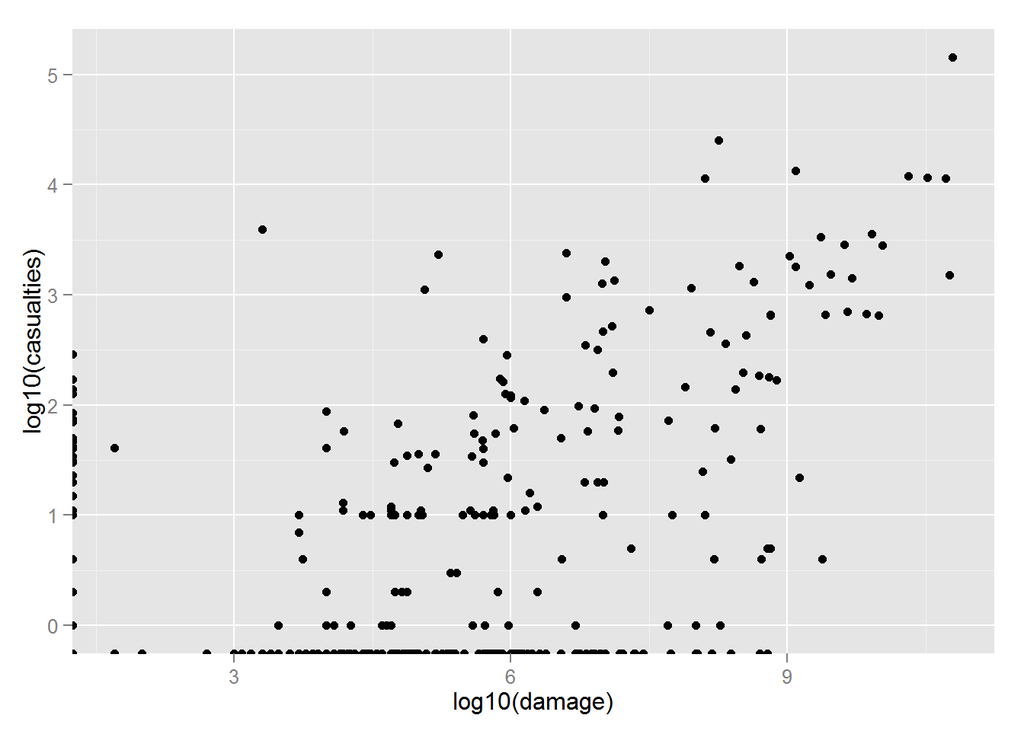

```r
suppressWarnings(library(ggplot2))
#With more time, draw the linear regression
ggplot(sumtbl, aes(log10(damage), log10(casualties))) + geom_point()
```

Let’s see which events create the most casualties.

```r
arrange(sumtbl, desc(casualties))
```

```
## Source: local data frame [979 x 3]
##
##            EVTYPE casualties      damage
## 1         TORNADO     143530 61770545074
## 2  EXCESSIVE HEAT      25555   178986957
## 3       LIGHTNING      13390  1227903961
## 4       TSTM WIND      11997 20333537524
## 5     FLASH FLOOD      11557 33143525687
## 6            HEAT      11470   126828642
## 7           FLOOD      11389 51536350415
## 8     RIP CURRENT       3912        2000
## 9       HIGH WIND       3557  8280028474
## 10   WINTER STORM       3341  2275746560
## ..            ...        ...         ...
```

And the most economic damage.

```r
arrange(sumtbl, desc(damage))
```

```
## Source: local data frame [979 x 3]
##
##               EVTYPE casualties      damage
## 1            TORNADO     143530 61770545074
## 2               HAIL       1507 57298711630
## 3              FLOOD      11389 51536350415
## 4        FLASH FLOOD      11557 33143525687
## 5          TSTM WIND      11997 20333537524
## 6  THUNDERSTORM WIND       2818 10760664364
## 7          HURRICANE        656  9689050278
## 8          HIGH WIND       3557  8280028474
## 9  HURRICANE/TYPHOON        671  7152389640
## 10          WILDFIRE       1431  5008844957
## ..               ...        ...         ...
```

Let’s see which `EVTYPE` are in the top 20 for both casualties and damage.

```r
c20 <- arrange(sumtbl, desc(casualties))[1:20,1]
d20 <- arrange(sumtbl, desc(damage))[1:20,1]
i <- intersect(c20, d20)
i
```

```
## Source: local data frame [12 x 1]
##
##                EVTYPE
## 1             TORNADO
## 2                HAIL
## 3               FLOOD
## 4         FLASH FLOOD
## 5           TSTM WIND
## 6   THUNDERSTORM WIND
## 7           HIGH WIND
## 8           ICE STORM
## 9  THUNDERSTORM WINDS
## 10       WINTER STORM
## 11           BLIZZARD
## 12          LIGHTNING
```

Here’s the best summary for a time-strapped government body.

```r
suppressWarnings(library(knitr))
kable(
        sumtbl %>%
        #Pick the events that are top 20 in both casualties and damage
        filter(EVTYPE %in% i$EVTYPE) %>%
        #Sort by casualties
        arrange(desc(casualties))
        )
```

| EVTYPE | casualties | damage |
| --- | --- | --- |
| TORNADO | 143530 | 61770545074 |
| LIGHTNING | 13390 | 1227903961 |
| TSTM WIND | 11997 | 20333537524 |
| FLASH FLOOD | 11557 | 33143525687 |
| FLOOD | 11389 | 51536350415 |
| HIGH WIND | 3557 | 8280028474 |
| WINTER STORM | 3341 | 2275746560 |
| ICE STORM | 2865 | 4173141074 |
| THUNDERSTORM WIND | 2818 | 10760664364 |
| BLIZZARD | 1815 | 1231431304 |
| THUNDERSTORM WINDS | 1547 | 2961010646 |
| HAIL | 1507 | 57298711630 |

Looks like governments should have responses (snow plows) as well as preventative measures (e.g. building codes, warning systems) to minimize casualties and economic damange from extreme weather.